# Interactive Parallel Computing on the Local Machine

*Computers have more than one core.* Wouldn't it be nice if we could use all the cores of our local machine from our [Jupyter](http://www.jupyter.org) notebook?

[Jupyter](http://www.jupyter.org) makes this fairly easy. One of the tabs of your browser has the title "Home". If you switch to that tab, there's are several tabs within the web page. One of them is called "IPython Clusters". Click on "IPython Clusters", increase the number of engines in the "default" profile to 4, and click on Start. The status changes from stopped to running. After you did that come back to this tab.

If the "Clusters" tab shows the message

```
Clusters tab is now provided by IPython parallel. See IPython parallel for installation details.
```

you need to quit your notebook server (make sure all your notebooks ar saved) and run the command

```
ipcluster nbextension enable
```

Now, when you start `jupyter notebook` you should see a field that lets you set the number of engines in the "IPython Clusters" tab.

Now let's see how we access the "Cluster". [IPython](http://www.ipython.org) comes with a module [ipyparallel](https://ipyparallel.readthedocs.io/en/latest/) that is used to access the engines, we just started. We first need to import Client.

```python
from ipyparallel import Client
```

```python
rc = Client(profile="default")
```

We can list the ids of the engines attached

```python
rc.ids
```

```
[0, 1, 2, 3]
```

and we create views of the engines by slicing.

```python
v01 = rc[0:2] # First two engines (0 and 1)
v23 = rc[2:4] # Engines 2 and 3
dview = rc[:] # All available engines
```

## Parallel Magic

IPython provides a magic command `%px` to execute code in parallel. The target attribute is used to pick the engines, you want.

Note, the commands prefixed with `%px` are *not* executed locally.

```python
%px import numpy as np # import numpy on all engines as np
import numpy as np # do it locally, too.
```

To execute a command both remotely and locally, you can use %%px and add `--local` as option.

```python
%%px --local
np.__version__ # print the numpy version of the engines. Not how the output is prefixed. It can be accessed that way, too.
```

```
'1.12.1'
```

```
Out[0:2]: '1.12.1'
```

```
Out[1:2]: '1.12.1'
```

```
Out[2:2]: '1.12.1'
```

```
Out[3:2]: '1.12.1'
```

The engines run ipython. Magic commands work, too.

```python
%px %matplotlib inline
```

```python
%matplotlib inline
```

```python
%px import matplotlib.pyplot as plt
import matplotlib.pyplot as plt
```

Sometimes it is useful to be able to execute more than a single statement. The cell magic command %%px lets us do that. The option `--target` lets us choose which engines we want to use. Here we are using engines 0 to 3.

```
[output:0]
```

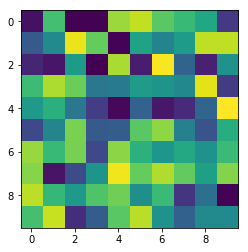

```
[output:1]
```

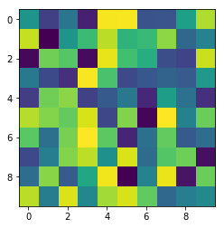

```
[output:2]
```

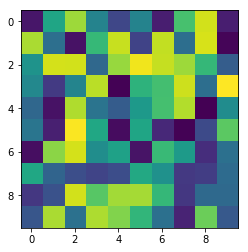

```
[output:3]
```

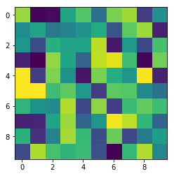

```
Out[0:5]: <matplotlib.image.AxesImage at 0x7f94d34204a8>
```

```
Out[1:5]: <matplotlib.image.AxesImage at 0x7f0e353fd4e0>
```

```
Out[2:5]: <matplotlib.image.AxesImage at 0x7f230e806518>
```

```
Out[3:5]: <matplotlib.image.AxesImage at 0x7fe14bb9a470>
```

```python
%%px --target 0:4
a = np.random.random([10,10])
plt.imshow(a, interpolation="nearest")
```

Yes, the output can be graphical.

Note that the imports, we performed with %px are not available in our notbook. We can fix that by using

```python
with rc[:].sync_imports():
    import matplotlib.pyplot
```

```
importing matplotlib.pyplot on engine(s)
```

Unfortunately mapping of namespaces does not work that way.